# Argonaut RIP-Microarray analysis

Uwe Schwartz

28 6 2019

## Dependencies

Microarray analysis was performed as recommended in the Bioconductor tutorial [An end to end workflow for differential gene expression using Affymetrix microarrays] (https://bioconductor.org/packages/devel/workflows/vignettes/maEndToEnd/inst/doc/MA-Workflow.html).

#### Install workflow

```r
if (!requireNamespace("BiocManager", quietly = TRUE))
  install.packages("BiocManager")

# The following initializes usage of Bioc devel
BiocManager::install(version='devel')
BiocManager::install("maEndToEnd")
```

#### Load packages

```r
suppressPackageStartupMessages({library("maEndToEnd")})
library(ggrepel)
library("clariomsmousehttranscriptcluster.db")
```

## Import data

First an annotation file was created describing the source of RNA used for analysis

```r
# path to files
raw_data_dir<-"data/2019-05-29_DanielaZeitler_MicroarrayNeumann_mir132-Target/CEL files/"

anno.data<-data.frame(condition=c(rep(c("input","IP"),c(2,4))),
           treatment=c("scr","inh","scr","scr","inh","inh"),
           row.names = list.files(raw_data_dir))
anno.data2<-cbind(anno.data,class=paste(anno.data$condition, anno.data$treatment, sep="_"))

anno.data2
```

```
##                       condition treatment     class
## P234_01_N_Scr_1.CEL       input       scr input_scr
## P234_02_N_Inh_3.CEL       input       inh input_inh
## P234_03_6F4_Scr_1.CEL        IP       scr    IP_scr
## P234_04_6F4_Scr_3.CEL        IP       scr    IP_scr
## P234_05_6F4_Inh_2.CEL        IP       inh    IP_inh
## P234_06_6F4_Inh_3.CEL        IP       inh    IP_inh
```

```r
SDRF <- AnnotatedDataFrame(anno.data2)
```

create an expression set object

```r
raw_data <- oligo::read.celfiles(filenames = file.path(raw_data_dir,
                                                       row.names(anno.data2)),
                                 verbose = FALSE, phenoData = SDRF)
```

## Exploratory data analysis

The PCA of the raw data was ploted

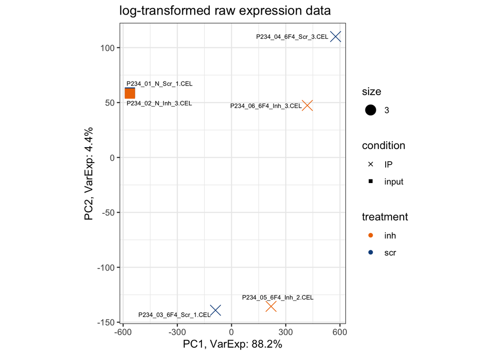

```r
exp_raw <- log2(Biobase::exprs(raw_data))
PCA_raw <- prcomp(t(exp_raw), scale. = FALSE)

percentVar <- round(100*PCA_raw$sdev^2/sum(PCA_raw$sdev^2),1)
sd_ratio <- sqrt(percentVar[2] / percentVar[1])

dataGG <- data.frame(PC1 = PCA_raw$x[,1], PC2 = PCA_raw$x[,2],
                     condition = pData(raw_data)$condition,
                     treatment = pData(raw_data)$treatment,
                     name = rownames(pData(raw_data)))

g<-ggplot(dataGG, aes(PC1, PC2, label=name))+
  geom_point(aes(shape = condition, colour = treatment, size=3)) +
  ggtitle("log-transformed raw expression data") +
  xlab(paste0("PC1, VarExp: ", percentVar[1], "%")) +
  ylab(paste0("PC2, VarExp: ", percentVar[2], "%")) +
  theme(plot.title = element_text(hjust = 0.5))+
  coord_fixed(ratio = sd_ratio) +
  scale_shape_manual(values = c(4,15)) +
  scale_color_manual(values = c("darkorange2", "dodgerblue4"))+
  theme_bw()+theme(aspect.ratio=4/3)
```

Input shows a clear separation from IP samples, however the RIP samples do not cluster together with their corresponding replicates (inhibitor and scrambled treatment).

Boxplots of log2-intensities of un-normalized samples

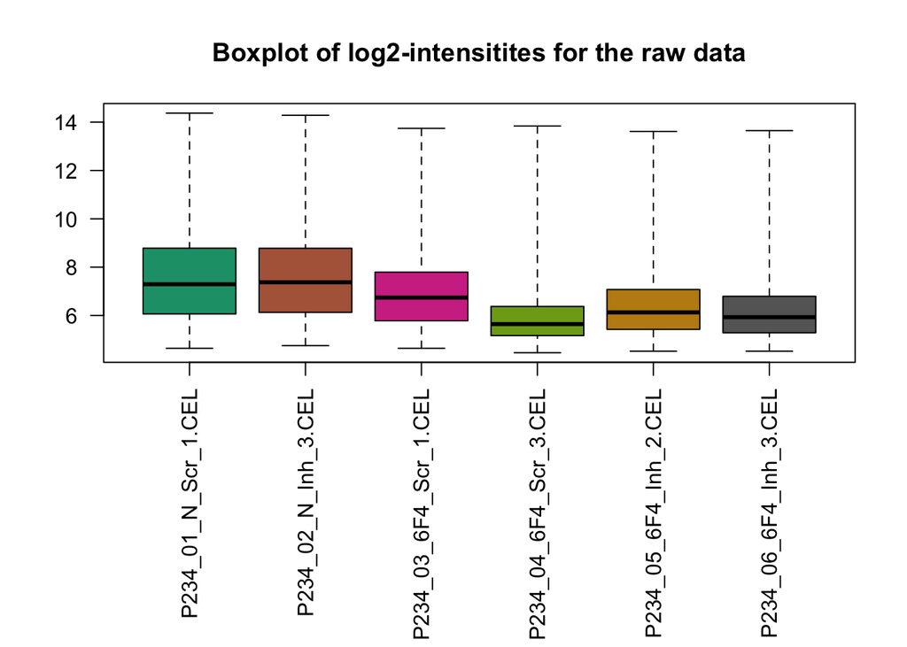

```r
oligo::boxplot(raw_data, target = "core", las=2,pars=list(par(mar=c(11,4,4,2))),
               main = "Boxplot of log2-intensitites for the raw data")
```

Deviation of expression intensity from the median expression of each array.

```r
palmieri_eset <- oligo::rma(raw_data, normalize = FALSE)
```

```
## Background correcting
## Calculating Expression
```

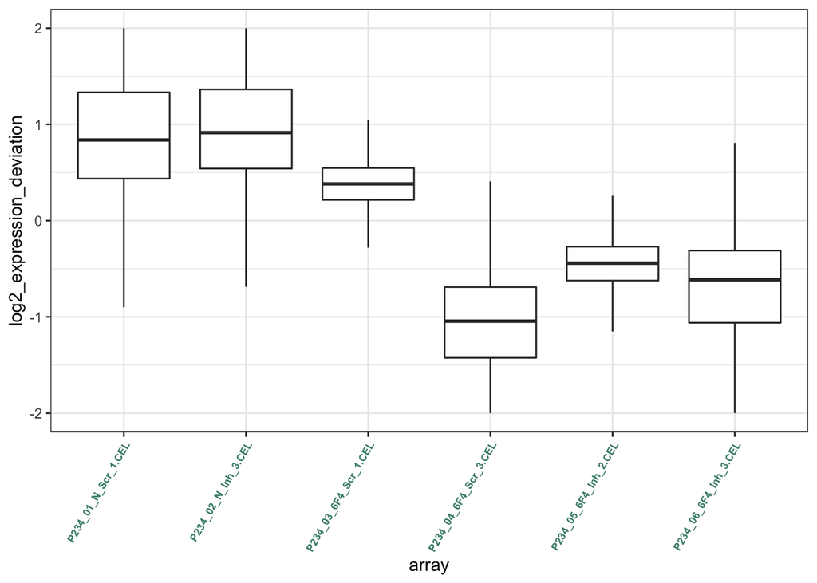

```r
row_medians_assayData <-
  Biobase::rowMedians(as.matrix(Biobase::exprs(palmieri_eset)))

RLE_data <- sweep(Biobase::exprs(palmieri_eset), 1, row_medians_assayData)

RLE_data <- as.data.frame(RLE_data)
RLE_data_gathered <-
  tidyr::gather(RLE_data, array, log2_expression_deviation)

g<-ggplot2::ggplot(RLE_data_gathered, aes(array,
                                          log2_expression_deviation)) +
  geom_boxplot(outlier.shape = NA) +
  ylim(c(-2, 2))+theme_bw() +
  theme(axis.text.x = element_text(colour = "aquamarine4",
                                   angle = 60, size = 6.5, hjust = 1 ,
                                   face = "bold"))
g
```

## Normalization

The data was normalized using the rma function of the oligo package. RMA shares information across arrays and uses the versatile quantile normalization method that will make the array intensity distributions match.The quantile normalization algorithm used by RMA works by replacing values by the average of identically ranked (within a single chip) values across arrays.

```r
palmieri_eset_norm <- oligo::rma(raw_data)
```

```
## Background correcting
## Normalizing
## Calculating Expression
```

### PCA analysis after normalization

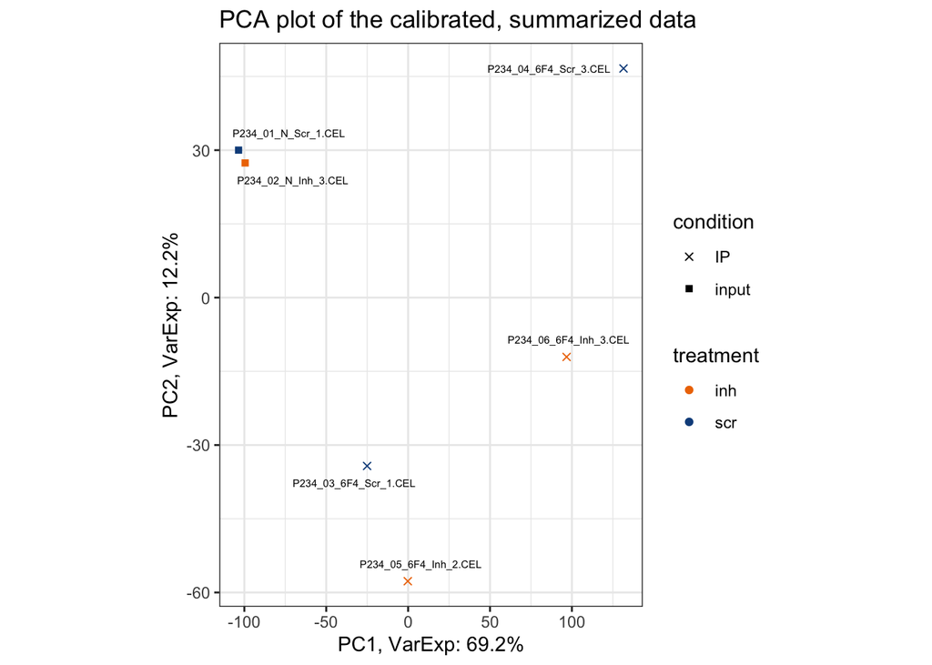

```r
######## PCA after norm
exp_palmieri <- Biobase::exprs(palmieri_eset_norm)
PCA <- prcomp(t(exp_palmieri), scale = FALSE)

percentVar <- round(100*PCA$sdev^2/sum(PCA$sdev^2),1)
sd_ratio <- sqrt(percentVar[2] / percentVar[1])

dataGG <- data.frame(PC1 = PCA$x[,1], PC2 = PCA$x[,2],
                     condition = pData(raw_data)$condition,
                     treatment = pData(raw_data)$treatment,
                     name = rownames(pData(raw_data)))

g<-ggplot(dataGG, aes(PC1, PC2, label=name))+
  geom_point(aes(shape = condition, colour = treatment)) +
  ggtitle("PCA plot of the calibrated, summarized data") +
  xlab(paste0("PC1, VarExp: ", percentVar[1], "%")) +
  ylab(paste0("PC2, VarExp: ", percentVar[2], "%")) +
  theme(plot.title = element_text(hjust = 0.5))+
  coord_fixed(ratio = sd_ratio) +
  scale_shape_manual(values = c(4,15)) +
  scale_color_manual(values = c("darkorange2", "dodgerblue4"))+
  theme_bw()+theme(aspect.ratio=4/3)

g+geom_label_repel(hjust = 0.5, size=2,label.size = NA, fill=NA)
```

### Sample-to-sample distances

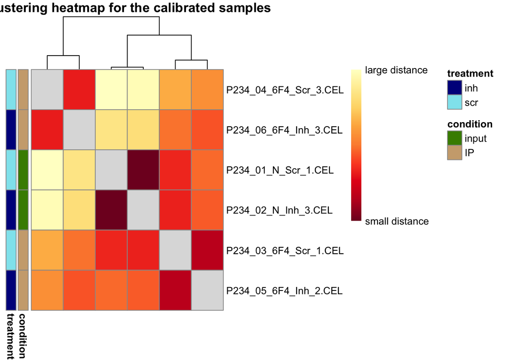

```r
condition_names <- ifelse(str_detect(pData(palmieri_eset_norm)$condition,
                                     "input"), "input", "IP")

treatment_names <- ifelse(str_detect(pData(palmieri_eset_norm)$treatment,
                                   "scr"), "scr", "inh")

annotation_for_heatmap <-data.frame(condition = condition_names,  treatment = treatment_names)
row.names(annotation_for_heatmap) <- row.names(pData(palmieri_eset_norm))

## calcualte distances
dists <- as.matrix(dist(t(exp_palmieri), method = "manhattan"))

rownames(dists) <- row.names(pData(palmieri_eset_norm))
hmcol <- rev(colorRampPalette(RColorBrewer::brewer.pal(9, "YlOrRd"))(255))
colnames(dists) <- NULL
diag(dists) <- NA

ann_colors <- list( condition= c(input = "chartreuse4", IP = "burlywood3"),
  treatment= c(inh = "blue4", scr = "cadetblue2"))


  pheatmap(dists, col = (hmcol),
           annotation_row = annotation_for_heatmap,
           annotation_colors = ann_colors,
           legend = TRUE,
           treeheight_row = 0,
           legend_breaks = c(min(dists, na.rm = TRUE),
                             max(dists, na.rm = TRUE)),
           legend_labels = (c("small distance", "large distance")),
           main = "Clustering heatmap for the calibrated samples")
```

After normalization RIP samples of the same treatment do not cluster together.

## Filtering

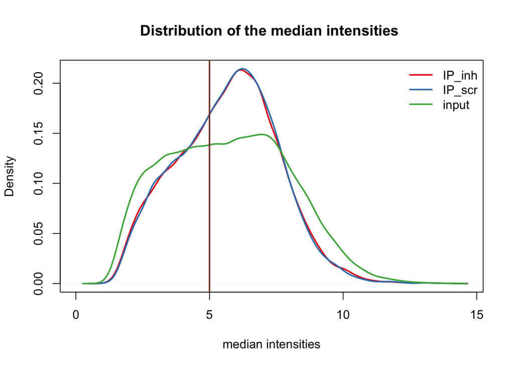

```r
palmieri_eset_norm$cond.class<-factor(c(rep("input",2),as.character(palmieri_eset_norm$class)[3:6]))

list.intensities<-list()
for(i in levels(palmieri_eset_norm$cond.class)){
  samps<-rownames(pData(palmieri_eset_norm))[(palmieri_eset_norm$cond.class ==i)]

  palmieri_medians <- rowMedians(Biobase::exprs(palmieri_eset_norm)[,samps])
  list.intensities[[i]]<-palmieri_medians
}
##### get overlay plot
#get maximums
max.x<-max(sapply(list.intensities, function(x) max(density(x)$x)))
max.y<-max(sapply(list.intensities, function(x) max(density(x)$y)))
cols.brew<-RColorBrewer::brewer.pal(4,"Set1")

  for(i in 1:length(list.intensities)){
    name<- names(list.intensities)[i]
    if(i==1){
      plot(density(list.intensities[[i]]),ylim=c(0,max.y), xlim=c(0,max.x),
           col=cols.brew[i], lwd=2, xlab="median intensities",
           main = "Distribution of the median intensities ")
    } else {
      lines(density(list.intensities[[i]]), lwd=2,col=cols.brew[i])
    }

  }
  legend("topright", legend = names(list.intensities), lwd=2, col=cols.brew, bty="n")
  abline(v = 5, col = "coral4", lwd = 2)
```

IP distribution is destinct from input distribution. Therefore, only IP values are used for filtering.Only probes with intensities > 5 in at least 2 IP samples are considered for further analysis

```r
########### filtering intensities higher in at least 2 samples of the IP
samples_cutoff <-2

# not input samples
samp.chx<-rownames(pData(palmieri_eset_norm))[pData(palmieri_eset_norm)$condition=="IP"]

idx_man_threshold <- apply(Biobase::exprs(palmieri_eset_norm)[,samp.chx], 1,
                           function(x){
                             sum(x > 5) >= samples_cutoff})
# filterd probes
table(idx_man_threshold)
```

```
## idx_man_threshold
## FALSE  TRUE
##  9479 19650
```

```r
palmieri_manfiltered <- subset(palmieri_eset_norm, idx_man_threshold)
```

19650 probes were used for further analysis

## Annotation of gene names

Probe IDs were converted to readable Gene Symbols. Probes, which cannot be assigned to a valid gene name were excluded.

```r
anno_palmieri <- AnnotationDbi::select(clariomsmousehttranscriptcluster.db,
                                       keys = (featureNames(palmieri_manfiltered)),
                                       columns = c("SYMBOL", "GENENAME"),
                                       keytype = "PROBEID")
anno_palmieri <- subset(anno_palmieri, !is.na(SYMBOL))

# get multimapping ids
anno_grouped <- group_by(anno_palmieri, PROBEID)
anno_summarized <-
  dplyr::summarize(anno_grouped, no_of_matches = n_distinct(SYMBOL))


## merge all gene names of those with multimapping ids
anno_filtered <- filter(anno_summarized, no_of_matches > 1)

probe_stats <- anno_filtered
#number of mult-ID probes
nrow(probe_stats)
```

```
## [1] 534
```

```r
multi.ids<-(anno_palmieri[(anno_palmieri$PROBEID %in% probe_stats$PROBEID),])
multi.symbols<-sapply(split(multi.ids,multi.ids$PROBEID),function(x) paste(x$SYMBOL,collapse = "/"))
multi.genenames<-sapply(split(multi.ids,multi.ids$PROBEID),function(x) paste(x$GENENAME,collapse = "/"))

ids_to_subset <- (anno_palmieri$PROBEID %in% probe_stats$PROBEID)
anno_palmieri <- subset(anno_palmieri, !ids_to_subset)


anno_palmieri_final<-rbind(anno_palmieri,
      data.frame(PROBEID=names(multi.symbols),SYMBOL=multi.symbols, GENENAME=multi.genenames))

## exclude not annotated probes
ids_to_keep <- (featureNames(palmieri_manfiltered) %in% anno_palmieri_final$PROBEID)

table(ids_to_keep)
```

```
## ids_to_keep
## FALSE  TRUE
##  3537 16113
```

```r
palmieri_final <- subset(palmieri_manfiltered, ids_to_keep)

fData(palmieri_final)$PROBEID <- rownames(fData(palmieri_final))
fData(palmieri_final) <- left_join(fData(palmieri_final), anno_palmieri_final)
```

16113 probes are left for differential analysis.

## Differential analysis

To identify significant changes in RNA composition of the pulled down Argonaut complex a linear model was fit. The main idea is to fit a linear model to the expression data for each gene. Empirical Bayes and other methods are used to borrow information across genes for the residual variance estimation leading to moderated t-statistics, and stabilizing the analysis for experiments with just a small number of arrays. Conceptually, the final per gene variance is a mix of a prior variance and the per gene variance.

```r
design<-model.matrix(~0+factor(c(1,1,2,2,3,3)))
colnames(design)<-c("input", "IP_scr", "IP_inh")
fit<-lmFit(palmieri_final, design)

contrast.matrix<-makeContrasts(input-IP_scr, input-IP_inh,IP_scr-IP_inh  ,levels = design)
fit2<-contrasts.fit(fit, contrast.matrix)
fit2<-eBayes(fit2)

expFinal<-exprs(palmieri_final)
## IPscr vs IPinh
res.IPscr_IPinh<-topTable(fit2, coef=3, number = Inf , adjust="BH")
res.IPscr_IPinh.ext<-cbind(res.IPscr_IPinh,expFinal[match(res.IPscr_IPinh$PROBEID, rownames(expFinal)),])

# show top hits
head(res.IPscr_IPinh.ext)
```

```
##                             PROBEID         SYMBOL
## TC0100001943.mm.2 TC0100001943.mm.2          Mybl1
## TC0700000567.mm.2 TC0700000567.mm.2 Igflr1/U2af1l4
## TC0600002800.mm.2 TC0600002800.mm.2          Lmod3
## TC1400002839.mm.2 TC1400002839.mm.2  Gm3500/Gm3373
## TC1700000656.mm.2 TC1700000656.mm.2         Hspa1l
## TC0100003015.mm.2 TC0100003015.mm.2        Map3k19
##                                                                                    GENENAME
## TC0100001943.mm.2                                            myeloblastosis oncogene-like 1
## TC0700000567.mm.2 IGF-like family receptor 1/U2 small nuclear RNA auxiliary factor 1-like 4
## TC0600002800.mm.2                                                       leiomodin 3 (fetal)
## TC1400002839.mm.2                                   predicted gene 3500/predicted gene 3373
## TC1700000656.mm.2                                                 heat shock protein 1-like
## TC0100003015.mm.2                         mitogen-activated protein kinase kinase kinase 19
##                       logFC  AveExpr         t     P.Value adj.P.Val
## TC0100001943.mm.2  1.695791 4.628769  5.342462 0.001410163 0.9996928
## TC0700000567.mm.2 -1.492435 7.180920 -4.808466 0.002461268 0.9996928
## TC0600002800.mm.2  1.394209 4.280850  4.704714 0.002755015 0.9996928
## TC1400002839.mm.2  1.922983 6.026161  4.689928 0.002799988 0.9996928
## TC1700000656.mm.2 -1.439721 4.946909 -4.569684 0.003197764 0.9996928
## TC0100003015.mm.2 -1.475371 4.507785 -4.441272 0.003693670 0.9996928
##                           B P234_01_N_Scr_1.CEL P234_02_N_Inh_3.CEL
## TC0100001943.mm.2 -4.437666            5.626618            5.350888
## TC0700000567.mm.2 -4.445660            7.995508            7.815366
## TC0600002800.mm.2 -4.447439            3.777598            3.934447
## TC1400002839.mm.2 -4.447700            6.806579            6.308771
## TC1700000656.mm.2 -4.449881            4.512159            4.732282
## TC0100003015.mm.2 -4.452344            4.735388            4.880468
##                   P234_03_6F4_Scr_1.CEL P234_04_6F4_Scr_3.CEL
## TC0100001943.mm.2              5.007955              5.085390
## TC0700000567.mm.2              6.256802              5.888087
## TC0600002800.mm.2              5.111609              5.269128
## TC1400002839.mm.2              6.928313              6.515477
## TC1700000656.mm.2              4.500497              4.278289
## TC0100003015.mm.2              3.907234              3.332823
##                   P234_05_6F4_Inh_2.CEL P234_06_6F4_Inh_3.CEL
## TC0100001943.mm.2              3.545830              3.155932
## TC0700000567.mm.2              7.517999              7.611760
## TC0600002800.mm.2              3.863744              3.728576
## TC1400002839.mm.2              5.211894              4.385931
## TC1700000656.mm.2              5.658066              6.000162
## TC0100003015.mm.2              5.055036              5.135763
```

0 significantly changed genes were detected after normalization for multiple testing. P-value distribution is shown below.

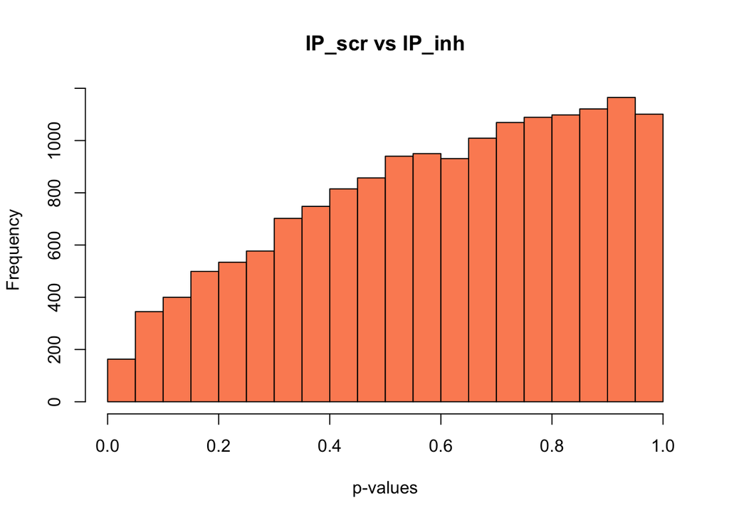

```r
  hist(res.IPscr_IPinh$P.Value, col = brewer.pal(3, name = "Set2")[2],
     main = "IP_scr vs IP_inh", xlab = "p-values")
```

Volcano plot highliting the top 20 genes

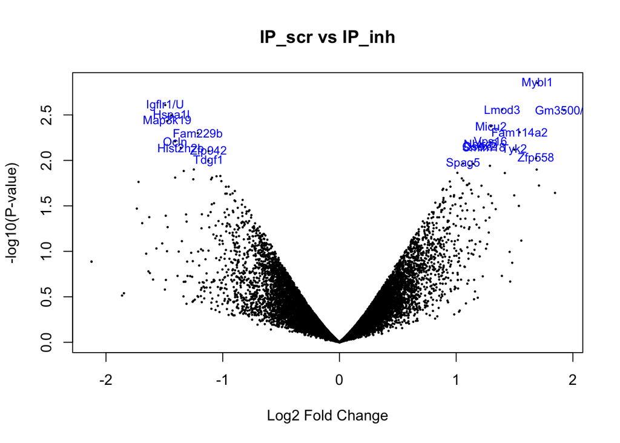

```r
  volcanoplot(fit2, coef = 3, style = "p-value", highlight = 20, names = fit2$genes$SYMBOL,
            xlab = "Log2 Fold Change", ylab = NULL, pch=16, cex=0.35, main=
              "IP_scr vs IP_inh")
```